# Advanced Visualizations Lecture 03

# Advanced Graphics and Data Visualization in R

# Lecture 03: `ggplot2` and adding those finishing touches

## 0.1.0 An overview of Advanced Graphics and Data Visualization in R

**“Advanced Graphics and Data Visualization in R”** is brought to you by the Centre for the Analysis of Genome Evolution & Function’s (CAGEF) bioinformatics training initiative. CSB1021 was developed to enhance the skills of students with basic backgrounds in R by focusing on available philosophies, methods, and packages for plotting scientific data. Many of the datasets and examples used in this course will be drawn from real-world datasets and the techniques learned herein aim to be broadly applicable to multiple fields.

This lesson is the third in a 6-part series. The aim for the end of this series is for students to recognize how to import, format, and display data based on their intended message and audience. The format and style of these visualizations will help to identify and convey the key message(s) from their experimental data.

The structure of the class is a **code-along style** in R markdown notebooks. At the start of each lecture, skeleton versions of the lecture will be provided for use on the [University of Toronto datatools Hub](https://datatools.utoronto.ca) so students can program along with the instructor.

## 0.2.0 Lecture objectives

Last week we did a deep dive on some of the more popular and broadly applicable visualizations for conveying basic ideas about your data. This week will focus on tidying up your visualizations and adding those extra finishing touches that will help polish them off. Adding, removing, altering graphs. Getting these little details correct help you to avoid alterations with additional software outside of R.

At the end of this lecture you will have covered the following topics

1. Altering and reproducing themes.
2. Setting and changing the content of titles, axes, text, and legends.
3. Annotating with text, and highlighting.
4. Altering your plot with new geoms, as well as data/axis/text manipulations.
5. Arranging plots together in the same figure.

## 0.3.0 A legend for text format in R markdown

`grey background` - a package, function, code, command or directory. Backticks are also use for in-line code.  
*italics* - an important term or concept or an individual file or folder  
**bold** - heading or a term that is being defined  
blue text - named or unnamed hyperlink

`...` - Within each coding cell this will indicate an area of code that students will need to complete for the code cell to run correctly.

**Blue box:** A key concept that is being introduced

**Yellow box:** Risk or caution

**Green boxes:** Recommended reads and resources to learn R

**Red boxes:** A comprehension question which may or may not involve a coding cell. You usually find these at the end of a section.

## 0.4.0 Lecture and data files used in this course

### 0.4.1 Weekly Lecture and skeleton files

Each week, new lesson files will appear within your RStudio folders. We are pulling from a GitHub repository using this [Repository git-pull link](https://r.datatools.utoronto.ca/hub/user-redirect/git-pull?repo=https%3A%2F%2Fgithub.com%2Fuoft-csb-datasci%2F2026-03-Adv_Graphics_R&urlpath=rstudio%2F&branch=main). Simply click on the link and it will take you to the [University of Toronto datatools Hub](https://datatools.utoronto.ca). You will need to use your UTORid credentials to complete the login process. From there you will find each week’s lecture files in the directory `/2026-03-Adv_Graphics_R/Lecture_XX`. You will find a partially coded `skeleton.Rmd` file as well as all the data files necessary to run the week’s lecture.

Alternatively, you can download the R-Markdown Notebook (`.Rmd`) and data files from the RStudio server to your personal computer if you would like to run independently of the Toronto tools.

### 0.4.2 Live-coding HTML page

A live lecture version will be available at [camok.github.io](https://uoft-csb-datasci.github.io/2026-03.Adv_Graphics_R/index.html) that will update as the lecture progresses. Be sure to refresh to take a look if you get lost!

### 0.4.3 Post-lecture HTMLs

At the end of each lecture there will be a completed version of the lecture code released as an HTML file under the Modules section of Quercus.

### 0.4.4 Data used in this lesson

Today’s datasets will focus on using a [Federal Respiratory Virus Detections dataset](https://www.canada.ca/en/public-health/services/surveillance/respiratory-virus-detections-canada.html). This data was used to compile a [weekly FluWatch report](https://www.canada.ca/en/public-health/services/diseases/flu-influenza/influenza-surveillance/weekly-influenza-reports.html). The data we’ll use today is a compilation of datasets from the 2022-23 season through to 2025-26. This will be an interesting dataset to look at since it contains datapoints across time regarding the testing and positive results for multiple respiratory viruses.

### 0.4.4.1 Dataset 1: Lecture03.RData

This dataframe will be found in the `Lecture03.RData` file and contains and full version of our datasets from Lecture 02 and Assignment 02. This file contains 2 objects:

1. `respFinalPop.df`: a full long-format version of our respiratory surveillance data from 2022-2026.
2. `top5Provinces`: a simple vector of the top 5 most heavily-testing provinces in the dataset based on 2023-2024 data.

## 0.5.0 Packages used in this lesson

`tidyverse` which has a number of packages including `dplyr`, `tidyr`, `stringr`, `forcats` and `ggplot2`

`viridis` helps to create color-blind palettes for our data visualizations

`lubridate` and `zoo` are helper packages used for working with date formats in R

`ggthemes`, `directlabels`, `ggforce`, `ggbeeswarm`, `gghighlight`, `ggExtra`, and `ggtext` will provide us new geoms and methods for plotting or altering how our plots look.

`ggpubr` will be used for arranging our plots AND adding some statistical information.

**Note**: As you install packages, you may be asked to update other packages along the way. Be sure to check the console window (lower window of RStudio) for a prompt and choose “None” as the option (usually a 3). The installations will not continue without answering the prompt.

```r
# None of these packages are already available on r.datatools
install.packages("ggthemes", dependencies = TRUE)
install.packages("directlabels", dependencies = TRUE)
remotes::install_version("ggforce", version = "0.4.2", repos = "http://cran.us.r-project.org")
install.packages("ggbeeswarm", dependencies = TRUE)
install.packages("gghighlight", dependencies = TRUE)
# ggExtra apparently relies on promises in some way but it is not a dependency
install.packages("promises")
install.packages("ggExtra", dependencies = TRUE)
install.packages("ggpubr", dependencies = TRUE)
install.packages("ggtext", dependencies = TRUE)
# A required package of ggtext
install.packages("xfun", dependencies = TRUE)
```

```
##
##   There are binary versions available but the source versions are later:
##       binary source needs_compilation
## knitr   1.38   1.51             FALSE
## xfun    0.30   0.57              TRUE
```

```
## installing the source packages 'litedown', 'knitr', 'xfun'
```

```r
# Packages to help tidy our data
library(tidyverse)

# Packages for the graphical analysis section
library(viridis)

# New visualisation packages
library(ggthemes)
library(directlabels)
library(ggforce)
library(ggbeeswarm)
library(gghighlight)
library(ggExtra)
library(ggpubr)
library(ggtext)
```

# 1.0.0 Present your data in its best format and *form*

Last week in lecture 2 we spent our time highlighting various types of plots and their variants while discerning the proper circumstances of their use. The focus of our plots was looking at proportions and distributions when dealing with population-based data. Now that we know which plots to use and when to use them, we can focus on how to clean up your visualizations so each can be presented as its “best self”.

Through both lectures and assignments we have already glimpsed at some of the commands and layers we can use to improve upon our graphs whether that is by choosing colour, titles, or legend information. Today we’ll explore those options more deeply so you don’t have to spend days trying to get your visualizations to look perfect. We’ll revisit some old plots and build them up from basics and tweak them to produce this:

[figure not shown]

By the time we finish today, we’ll know how to manipulate many of the elements of a ggplot.

### 1.0.1 Load class data with the `load()` function

Let’s start with our respiratory surveillance data from Lecture 02 which consists of four seasons of observations. It’s saved conveniently in our `Lecture03.RData` file. After loading we’ll take a quick look at the structure of our main data file `respFinalPop.df`.

```r
# Load some pregenerated data tables for class
# Load Lecture03.RData
load("./data/Lecture03.RData")
ls()
```

```
##  [1] "currMod"                "destinationDir"         "fname"
##  [4] "fout"                   "gitCred"                "githubDir"
##  [7] "lastMod"                "lec03.theme"            "lectureDir"
## [10] "lectureName"            "mainDir"                "originDir"
## [13] "renderOut"              "repo"                   "repoLocal"
## [16] "repoURL"                "respFinalPop.df"        "respLine.plot"
## [19] "respObsSummary.df"      "respScatter.plot"       "respViolin.plot"
## [22] "termDir"                "termGit"                "timeout"
## [25] "top5Provinces"          "top5Provinces_initials"
```

```r
# Remind ourselves what respFinalPop.df looks like
str(respFinalPop.df)
```

```
## tibble [16,339 x 12] (S3: tbl_df/tbl/data.frame)
##  $ season             : chr [1:16339] "2023-2024" "2023-2024" "2023-2024" "2023-2024" ...
##  $ week               : num [1:16339] 23 23 23 23 23 23 23 23 23 23 ...
##  $ endingDate         : Date[1:16339], format: "2024-06-08" "2024-06-08" ...
##  $ year               : num [1:16339] 2024 2024 2024 2024 2024 ...
##  $ month              : Ord.factor w/ 12 levels "Jan"<"Feb"<"Mar"<..: 6 6 6 6 6 6 6 6 6 6 ...
##  $ yearMonth          : Date[1:16339], format: "2024-06-01" "2024-06-01" ...
##  $ reportingLaboratory: chr [1:16339] "Newfoundland" "Newfoundland" "Newfoundland" "Newfoundland" ...
##  $ population         : num [1:16339] 548402 548402 548402 548402 548402 ...
##  $ virus              : chr [1:16339] "SARS-CoV-2" "Influenza" "RSV" "HPIV" ...
##  $ tests              : num [1:16339] 669 581 581 581 581 581 581 581 104 47 ...
##  $ detections         : num [1:16339] 95 4 3 33 2 9 85 9 14 0 ...
##  $ percentPositive    : num [1:16339] 14.2 0.688 0.516 5.68 0.344 ...
```

```r
# What are the top provinces?
top5Provinces
```

```
## [1] "Ontario"          "Québec"           "British Columbia" "Alberta"
## [5] "Manitoba"
```

### 1.0.2 Generate a line graph of our data looking at changes in positivity over time

We’ll start off with a simple figure of positivity for influenza and SARS-CoV-2 in our top 5 provinces over 4 seasons. To build this line graph we’ll use our entire dataset found in `respFinalPop.df`.

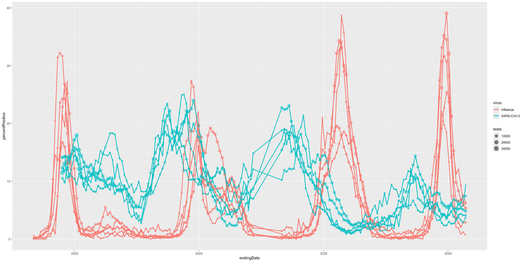

```r
# 1.0.2 Generate a basic line graph of SARS and Influenza positivity

# Pass along the dataset
respFinalPop.df %>%
  # Filter for 2 viruses and 5 provinces
  filter(
         virus %in% c("Influenza", "SARS-CoV-2"),
         reportingLaboratory %in% top5Provinces
         ) %>%

  ggplot() +
    # 2. Aesthetics
    aes(x = endingDate,
        y = percentPositive,
        colour = virus) +

    # 4. Geoms
    # Add a line and group based on lab+virus
    geom_line(aes(group = interaction(reportingLaboratory, virus)), linewidth = 1) +

    # Add a point for each data but make its size based on the number of tests
    geom_point(aes(size = tests), alpha = 0.5)
```

From our above plot, we can immediately see some obvious issues that need remedying:

1. The overall font size of the plot is small (and I have old eyes).
2. The size of the points start off too small for me (again, old eyes)
3. There is no way to distinguish which lines belong to which provinces
4. The legend and axes names need to be updated along with some additional tick marks for clarity. We could use a title too. We’ll fix this problem later!

## 1.1.0 Control the display of all non-data elements with `theme()`

Although we haven’t directly discussed themes yet, we have seen it appearing here and there in our individual plots. The influence of `theme()` sets and controls the *presentation* of titles, labels, text, background, legends, etc. You don’t directly change the actual information presented in these elements.

Calls to `theme()` generally take the form of `theme(element.component.sub-component = element_*(parameter = value))`

Some basic elements include line, rect, text, title, and aspect.ratio. Altering these elements in `theme()` will alter all elements of their kind (ie all lines, rectangles, text etc.). Alternatively, specific element components can be altered more directly. The following table lists most of the possible theme elements and components. They can be as specific as `axis.title.x.top`. More detailed descriptions can be found [here](https://ggplot2.tidyverse.org/reference/theme.html).

| Element | Description | Components | Sub-components | Other |
| --- | --- | --- | --- | --- |
| axis | x and y axis elements | title, text, ticks, line | x, y, length | top, bottom, left, right |
| legend | all legend elements | background, margin, spacing, key, text, title, position, direction, justification, box | x, y, size, height, width, align, just, spacing |  |
| panel | background plotting area | background, border, spacing, grid | x, y, major, minor |  |
| plot | entire plot | background, title, subtitle, caption, tax, margin | position |  |
| strip | facet labels | background, placement, text, switch | x, y, text, pad | grid, wrap |

You update or set your individual elements using the `element_*()` functions. Within each element you can typically control aesthetics like fill, colour/color, size, etc. Below is a summary of the elements of concern and their parameters. Specific `elements_*()` will correspond with the above `theme` elements.

| element call | description | fill | colour | size | linetype | lineend | arrow | family | face | hjust | vjust | angle | lineheight | margin |
| --- | --- | --- | --- | --- | --- | --- | --- | --- | --- | --- | --- | --- | --- | --- |
| element_line() | formatting of lines |  | $\checkmark$ | $\checkmark$ | $\checkmark$ | $\checkmark$ | $\checkmark$ |  |  |  |  |  |  |  |
| element_text() | formatting of text |  | $\checkmark$ | $\checkmark$ |  |  |  | $\checkmark$ | $\checkmark$ | $\checkmark$ | $\checkmark$ | $\checkmark$ | $\checkmark$ | $\checkmark$ |
| element_rect() | borders and background | $\checkmark$ | $\checkmark$ | $\checkmark$ | $\checkmark$ |  |  |  |  |  |  |  |  |  |
| element_blank() | draws nothing, and assigns no space |  |  |  |  |  |  |  |  |  |  |  |  |  |

`inherit.blank` is an additional parameter you can use in these functions that is normally set to `FALSE`. When set to `TRUE`, if a parental layer uses `element_blank()`, it will cause this element to be blank as well.

For example `axis.title` is the parent of `axis.title.x`. By setting the `inherit.blank = TRUE` parameter, you can override/nullify aesthetics assignment layers as long as a parent layers has set those elements to `element.blank()`. It’s a good way to remove additional layer effects if needed!

### 1.1.1 Move your legend(s) using the `legend.position` option

Let’s start with one of the most oft-intrusive components of our visualizations. While necessary, legends often default to the right-hand side of our visualizations where they can take up extra horizontal space without requiring much vertical space! In the `ggplot` package, legends may be coded by parameters or layers that describe it as a “legend” or “guide”.

### 1.1.1.1 Moving your legend within the plot area

When we are looking to move our legends to different positions, there are 2 areas to consider. The first is the plot area itself which *surrounds* the data panel (where our data is plotted). As of ggplot 3.5.0 there are a few options to move the legend around. The simplest is the `legend.position` parameter which will accept a character argument of “top”, “bottom”, “left”, “right”, or “inside”.

Let’s start with altering our legend position within the plot area. It’s taking up quite a bit of space on the side. We’ll worry about the label issues later. For now, let’s move the legend to the bottom of the plot.

At the same time, let’s increase our overall text size for the plot. We have, through many of our visualizations in previous lectures updated the `text` parameter with `element_text()`. You’ll notice also that we can put multiple elements into the same `theme()` call BUT you could also separate them into individual or grouped elements as well.

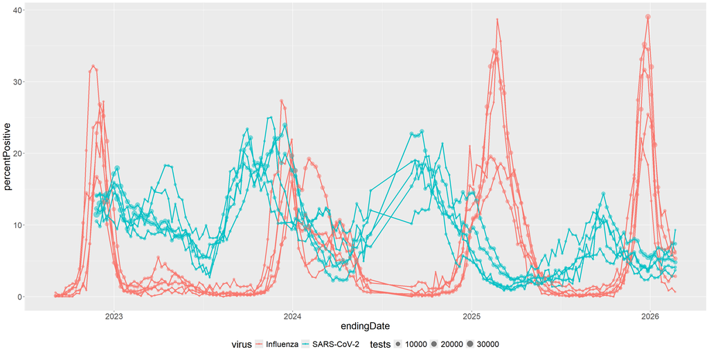

```r
# 1.1.1.1 Move the legend around on the panel

# Pass along the dataset
respFinalPop.df %>%
  # Filter for 2 viruses and 5 provinces
  filter(
         virus %in% c("Influenza", "SARS-CoV-2"),
         reportingLaboratory %in% top5Provinces
         ) %>%

  ggplot() +
    # 2. Aesthetics
    aes(x = endingDate, y = percentPositive, colour = virus) +

    # Theme elements
    theme(text = element_text(size=20), # set text size to 20
          ### 1.1.1.1 Move the legend to the bottom
          legend.position = "bottom"
         ) +

    # 4. Geoms
    # Add a line and group based on lab+virus
    geom_line(aes(group = interaction(reportingLaboratory, virus)), linewidth = 1) +

    # Add a point for each data but make it's size based on the number of tests
    geom_point(aes(size = tests), alpha = 0.5)
```

### 1.1.1.2 Move a legend to within your data panel with `legend.position = inside`

Instead of moving the legend to the bottom of our plot area, let’s use the empty space in the top left corner of the *data panel* instead by accessing the coordinate system (0:1, 0:1) that represents the relative positioning of elements within the panel.

To accomplish this movement we need a few theme parameters/arguments:

1. `legend.position = "inside"` which globally sets all legends to the inside panel
2. `legend.position.inside = c(x,y)` parameter which actually comes with 5 total variants dependent upon the `legend.position` parameter:
- `legend.position.inside`: place one or more legends *inside* the plot panel. This is what we want to use next!
- `legend.position.top`: place one or more legends on the top of the figure
- `legend.position.bottom`: place one or more legends on the bottom of the figure
- `legend.position.right`: place one or more legends on the right of the figure
- `legend.position.left`: place one or more legends on the left of the figure

This system, follows a `c(x, y)` setup that represents the data panel with (0,0) meaning the lower left corner and (1,1) being the top right corner. This function moves the legend’s anchor at the specified coordinate in the theme-specified area of the plot. So now, not only can you fine-tune the position of a legend within the plot space, you can do so on the “margin” areas of your plot as well! You can set these theme parameters globally for all legends or you can choose where specific legends (if you have multiple) will go using the `position` parameter in the `guides()` or similar layers.

3. `legend.justification` chooses the anchor position on the legend(s). Before we move the legend onto our panel we also have to remember *where* the legend itself is anchoring when we move it. Are we asking to put the bottom-right corner of the legend into the top-left corner of the plot? Or do we want to match the legend anchor so that the top-left corners are aligned? Use the `legend.justification` parameter to properly set the anchor when moving your legend. This parameter also accepts a `c(x,y)` coordinate argument like the one used for `legend.position`.

**Other changes:**

- At the same time, we’ll make a quick adjustment to `ylim()` in order to make sure our legend doesn’t cover any data points. We’ll use the form `ylim(NA, value)` to tell ggplot to pick a lower limit based on the dataset, but use a specific upper limit.

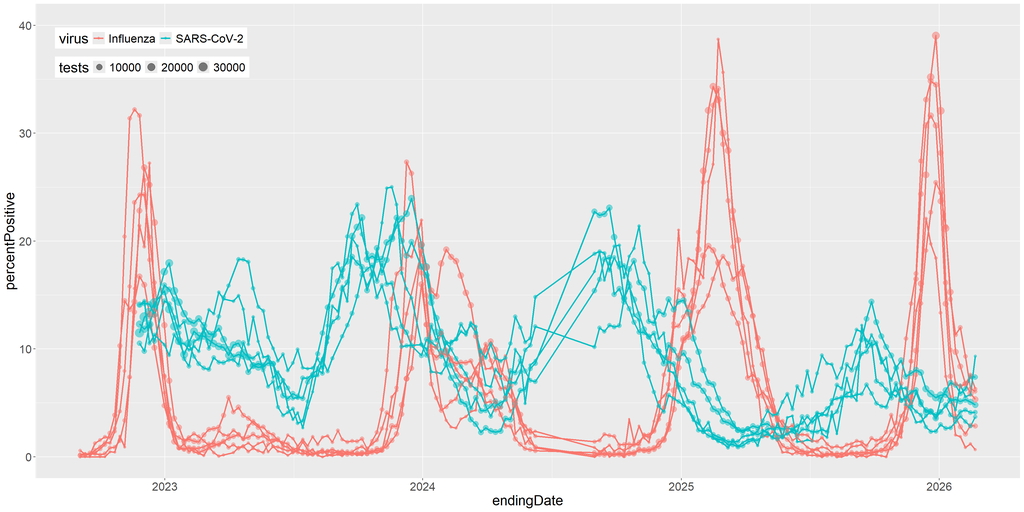

```r
# 1.1.1.2 Move the legend to within the data panel

# Pass along the dataset
respFinalPop.df %>%
  # Filter for 2 viruses and 5 provinces
  filter(
         virus %in% c("Influenza", "SARS-CoV-2"),
         reportingLaboratory %in% top5Provinces
         ) %>%

  ggplot() +
    # 2. Aesthetics
    aes(x = endingDate, y = percentPositive, colour = virus) +

    # Theme elements
    theme(text = element_text(size=20), # set text size to 20
          ### 1.1.1.2 Move the legend around to within the panel space
          legend.justification = c(0,1),                 # Set the anchor on the legend you are moving
          legend.position = "inside",                    # Position the legend inside the plot panel
          legend.position.inside = c(0.02,0.95),         # Set the point where you are moving the legend anchor
          legend.direction = "horizontal"
         ) +

    # 3. Scaling
    ### 1.1.1.2 Set the y-axis upper limit to 40
    ylim(NA, 40) +

    # 4. Geoms
    # Add a line and group based on lab+virus
    geom_line(aes(group = interaction(reportingLaboratory, virus)), linewidth = 1) +

    # Add a point for each data but make it's size based on the number of tests
    geom_point(aes(size = tests), alpha = 0.5)
```

## 1.1.2 Update the background panel and lines

There are a few more things we can do to the plot for now that include updating the background panel to get rid of the grey colour and darkening our axis tick lines and axis lines themselves.

1. We’ll use the `panel.background` parameter which expects an `element_rect()` to define it’s properties.
2. `panel.grid.*` gives us access to the background axes lines using `element_line()`
3. We’ll work with `axis.*` elements to to update their format a bit too.
4. Let’s spice up the `plot` a little bit by setting the overall background colour.

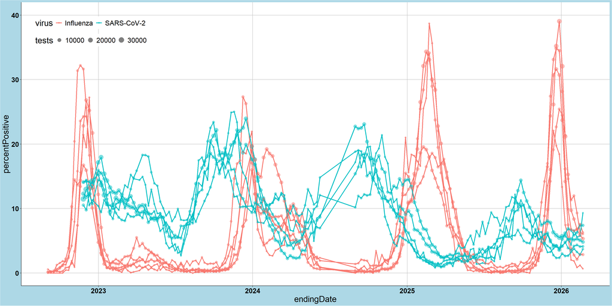

```r
# 1.1.2 Update around the background panel and lines

# Pass along the dataset
respFinalPop.df %>%
  # Filter for 2 viruses and 5 provinces
  filter(
         virus %in% c("Influenza", "SARS-CoV-2"),
         reportingLaboratory %in% top5Provinces
         ) %>%

  ggplot() +
    # 2. Aesthetics
    aes(x = endingDate, y = percentPositive, colour = virus) +

    # Theme elements
    theme(text = element_text(size=20), # set text size to 20

          # Move the legend around to within the panel space
          legend.justification = c(0,1),                 # Set the anchor on the legend you are moving
          legend.position = "inside",                    # Position the legend inside the plot panel
          legend.position.inside = c(0.02,0.95),         # Set the point where you are moving the legend anchor
          legend.direction = "horizontal",

          ### 1.1.2 Update the panel colour and line colours
          panel.background = element_rect("white"),
          panel.grid.major = element_line("grey"),

          ### 1.1.2 Use a black line for the axes
          axis.line = element_line(colour="black"),
          axis.text = element_text(colour="black", face="bold"),

          ### 1.1.2 Update the plot background colour
          plot.background = element_rect("lightblue")
         ) +

    # 3. Scaling
    # Set the y-axis upper limit to 40
    ylim(NA, 40) +

    # 4. Geoms
    # Add a line and group based on lab+virus
    geom_line(aes(group = interaction(reportingLaboratory, virus)), linewidth = 1) +

    # Add a point for each data but make it's size based on the number of tests
    geom_point(aes(size = tests), alpha = 0.5)
```

## 1.2.0 Use premade themes from `ggplot2`

In our above example we made alterations to the theme that affected background colour and axis lines. While some of you may lean on the more artistic side you can also use premade themes from both the `ggplot2` package and additional packages like `ggthemes`. Below you’ll find a list of the themes from `ggplot2`.

| Theme | Description |
| --- | --- |
| theme_gray() | Grey background colour, white grid lines. |
| theme_bw() | White background colour, grey grid lines. |
| theme_linedraw() | White background colour, black lines of various widths |
| theme_light() | White background colour, grey lines of various widths |
| theme_dark() | Dark background colour, grey lines of various widths |
| theme_minimal() | No background annotations, grey lines |
| theme_classic() | White background, x/y axis lines, no grid lines |
| theme_void() | A completely empty themes, white background, no axis or grid lines |

If you find a theme that you *mostly* like, you can use that as a base to your graph *before* making additional `theme()` alterations. Let’s try a few of these out. We’ll take the time to also drop our blue plot background.

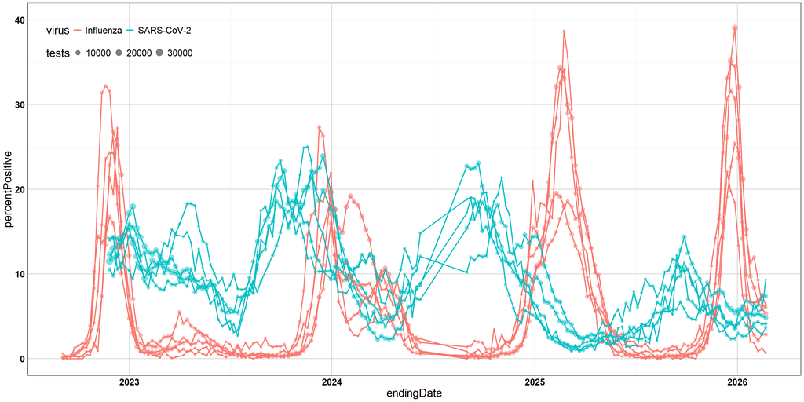

```r
# 1.2.0 Play around with different themes

# Save the plot to a variable
respLine.plot <-
  # Pass along the dataset
  respFinalPop.df %>%
  # Filter for 2 viruses and 5 provinces
  filter(
         virus %in% c("Influenza", "SARS-CoV-2"),
         reportingLaboratory %in% top5Provinces
         ) %>%

  ggplot() +
    # 2. Aesthetics
    aes(x = endingDate, y = percentPositive, colour = virus) +

    # Theme elements
    ### 1.2.0 Start with a base theme
    theme_minimal() +

    theme(text = element_text(size=20), # set text size to 20

          # Move the legend around to within the panel space
          legend.justification = c(0,1),                 # Set the anchor on the legend you are moving
          legend.position = "inside",                    # Position the legend inside the plot panel
          legend.position.inside = c(0.02,0.95),         # Set the point where you are moving the legend anchor
          legend.direction = "horizontal",

          # Update the panel colour and line colours
          panel.background = element_rect("white"),
          panel.grid.major = element_line("grey"),

          # Use a black line for the axes
          axis.line = element_line(colour="black"),
          axis.text = element_text(colour="black", face="bold")

         ) +

    # 3. Scaling
    # Set the y-axis upper limit to 40
    ylim(NA, 40) +

    # 4. Geoms
    # Add a line and group based on lab+virus
    geom_line(aes(group = interaction(reportingLaboratory, virus)), linewidth = 1) +

    # Add a point for each data but make it's size based on the number of tests
    geom_point(aes(size = tests), alpha = 0.5)

# View the plot
respLine.plot
```

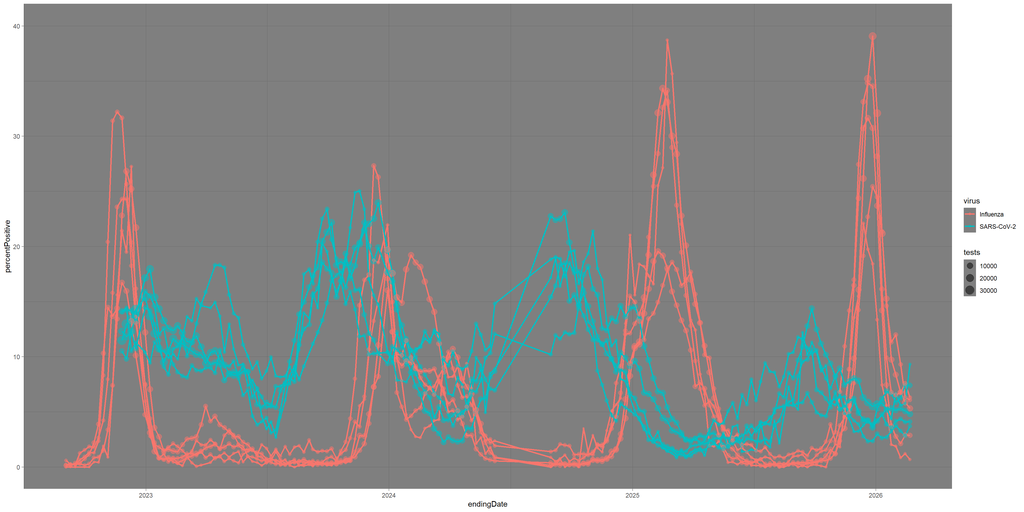

```r
# Try to add theme_dark() to our plot. What are the consequences?
respLine.plot + theme_dark()
```

**Layer order matters!** It cannot be stressed enough that layer order matters. We’ve mentioned it in previous sections as we work through these figures but the above code is our clearest example. Even though we had set the font formats, and legend positions, all of that was erased with a single added **theme_dark()** layer. This is because the *most recent layer* overrides all of the aesthetics from previous ones. Sometimes this has only a small effect depending on the inheritance structure or it can essentially reset everything! *Caveat emptor!*

## 1.3.0 `ggthemes` mimics visual styles from multiple sources

If you are feeling a little more daring with your choices, you can turn to the `ggthemes` packages to mimic styles from a number of publications such as the Economist, and Wall Street Journal. You can look up a list of the various themes at https://github.com/jrnold/ggthemes.

Like the themes provided by ggplot, you can also make edits to these themes within your scripts.

Two additional package options with different colour palettes and shapes are `ggthemr` and `ggsci`.

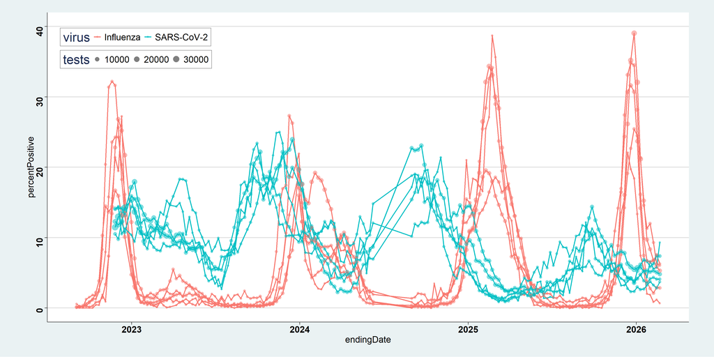

```r
# 1.3.0 Play around with different themes

# Pass along the dataset
respFinalPop.df %>%
  # Filter for 2 viruses and 5 provinces
  filter(
         virus %in% c("Influenza", "SARS-CoV-2"),
         reportingLaboratory %in% top5Provinces
         ) %>%

  ggplot() +
    # 2. Aesthetics
    aes(x = endingDate, y = percentPositive, colour = virus) +

    # Theme elements
    ### 1.3.0 Switch to the stata theme
    theme_stata() +

    theme(text = element_text(size=20), # set text size to 20

          # Move the legend around to within the panel space
          legend.justification = c(0,1),                 # Set the anchor on the legend you are moving
          legend.position = "inside",                    # Position the legend inside the plot panel
          legend.position.inside = c(0.02,0.95),         # Set the point where you are moving the legend anchor
          legend.direction = "horizontal",

          # Update the panel colour and line colours
          panel.background = element_rect("white"),
          panel.grid.major = element_line("grey"),

          # Use a black line for the axes
          axis.line = element_line(colour="black"),
          axis.text = element_text(colour="black", face="bold")

         ) +

    # 3. Scaling
    # Set the y-axis upper limit to 40
    ylim(NA, 40) +

    # 4. Geoms
    # Add a line and group based on lab+virus
    geom_line(aes(group = interaction(reportingLaboratory, virus)), linewidth = 1) +

    # Add a point for each data but make it's size based on the number of tests
    geom_point(aes(size = tests), alpha = 0.5)
```

## 1.4.0 Create and save your own custom themes

When working on projects to produce plots for a presentation, thesis or manuscript, you can generally create your own themes and save them as a variable. This create flexibility in a number of ways including:

1. Centralizing your theme code to a single variable so it can be called upon within multiple plots. This will also minimize redundant code!
2. Standardizing your plot themes to ensure they are consistently using the same theme.
3. Simplifying the modification of your plot themes including plot font size which may vary between presentation and journal publishers!

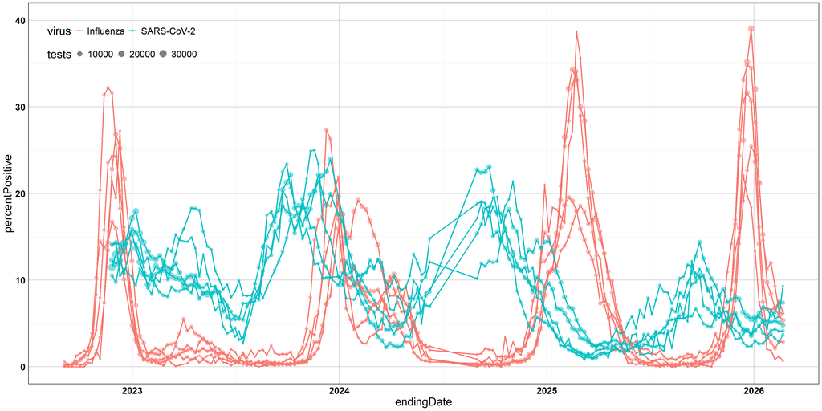

```r
### 1.4.0 create a theme

lec03.theme <-
  theme_minimal() +
  theme(text = element_text(size=20), # set text size to 20

        # Move the legend around to within the panel space
        legend.justification = c(0,1),                 # Set the anchor on the legend you are moving
        legend.position = "inside",                    # Position the legend inside the plot panel
        legend.position.inside = c(0.02,0.95),         # Set the point where you are moving the legend anchor
        legend.direction = "horizontal",

        # Update the panel colour and line colours
        panel.background = element_rect("white"),
        panel.grid.major = element_line("grey"),

        # Use a black line for the axes
        axis.line = element_line(colour="black"),
        axis.text = element_text(colour="black", face="bold"),

        plot.background = element_rect(fill = "white", color = NA)
        )


# rebuild our plot using our theme variable
# Pass along the dataset
respFinalPop.df %>%
  # Filter for 2 viruses and 5 provinces
  filter(
         virus %in% c("Influenza", "SARS-CoV-2"),
         reportingLaboratory %in% top5Provinces
         ) %>%

  ggplot() +
    # 2. Aesthetics
    aes(x = endingDate, y = percentPositive, colour = virus) +

    # Theme elements
    ### 1.4.0 Use the theme variable you just created!
    lec03.theme +

    # 3. Scaling
    # Set the y-axis upper limit to 40
    ylim(NA, 40) +

    # 4. Geoms
    # Add a line and group based on lab+virus
    geom_line(aes(group = interaction(reportingLaboratory, virus)), linewidth = 1) +

    # Add a point for each data but make it's size based on the number of tests
    geom_point(aes(size = tests), alpha = 0.5)
```

# 2.0.0 Text content can be updated through a number of layers

Now that we have played around with how to reposition legends, and other elements of your plot, we can discuss how to change the *actual* text content of your plot. Many times we want to relabel axes or legends, even legend labels. There are a number of layers we can work through but we’ll present some of the simplest ways to accomplish this.

## 2.1.0 Label titles and axes individually or with the `labs()` command

Up to this point, we’ve seen the use of different commands to alter the labels and titles like:

- `xlab()`: Update the x-axis label.
- `ylab()`: Update the y-axis label.
- `ggtitle()`: Update the plot title.

Instead of multiple layers, you can access multiple title options within a single call to the `labs()` layer which accepts the following parameters:

- `...`: a list of name-value pairs that map back to an aesthetic (ie `x = "X-axis"` or `colour = "Population"`)
- Use the `NULL` value to remove a title for a specific label.
- `title`, `subtitle`: the title with a subtitle displayed below
- `caption`: the text for the caption is displayed in the bottom-right by default
- `tag`: figure text tag/label usually for figure panels in manuscripts

Let’s relabel our plot axis and titles to be more accurate. For now we’ll drop the **Stata** theme and go with our own alteration of `theme_minimal()`. We’ll also include a caption in the bottom right to explain that we are only using a subset of provinces in the figure. You’ll also notice that the legend title will be quite easily fixed!

**Note**: a quick way of adding space to your titles, is to include the `\n` character which inserts a carriage return.

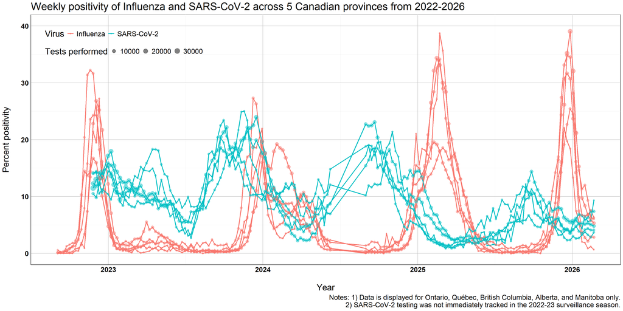

```r
# 2.1.0 Relabel and add extra titles

# Pass along the dataset
respFinalPop.df %>%
  # Filter for 2 viruses and 5 provinces
  filter(
         virus %in% c("Influenza", "SARS-CoV-2"),
         reportingLaboratory %in% top5Provinces
         ) %>%

  ggplot() +
    # 2. Aesthetics
    aes(x = endingDate, y = percentPositive, colour = virus) +

    # Theme elements
    # Start with a base theme
    lec03.theme +

    ### 2.1.0 Add labels to our plot
    labs(title = "Weekly positivity of Influenza and SARS-CoV-2 across 5 Canadian provinces from 2022-2026",
         x = "\nYear",
         y = "Percent positivity\n",
         colour = "Virus",
         size = "Tests performed",
         caption = "Notes: 1) Data is displayed for Ontario, Québec, British Columbia, Alberta, and Manitoba only.\n 2) SARS-CoV-2 testing was not immediately tracked in the 2022-23 surveillance season.") +

    # 3. Scaling
    # Set the y-axis upper limit to 40
    ylim(NA, 40) +

    # 4. Geoms
    # Add a line and group based on lab+virus
    geom_line(aes(group = interaction(reportingLaboratory, virus)), linewidth = 1) +

    # Add a point for each data but make it's size based on the number of tests
    geom_point(aes(size = tests), alpha = 0.5)
```

## 2.2.0 Relabel axis ticks, and legend labels with the `labels` parameter

In last lecture’s assignment, you likely would have used the `xlim()` or `ylim()` layers to set the axis limits on some of your visualizations. As with all things, there is more than one pathway to our goals.

The `scale_*()` functions can also be used to set the title, limits, breaks, and labels along your axes. Some of these parameters are redundant and can override other `ggplot2` layer commands, depending on the order you have included them.

| Parameter | Equivalent ggplot layer command |
| --- | --- |
| name | xlab(), ylab(), lab(x), lab(y) |
| limits | xlim(), ylim() |
| break | Determine when axis tick marks are generated |
| labels | *Rename* the labels present at axis tick marks |

### 2.2.1 Adjust your axis text with the `element_text()` function

Let’s revisit the `axis.text.x` component of theme to break down some alterations we’ve been making in previous lectures. There are a few things we can use to influence the rendering of `element_text()` including:

- `angle`: use this to rotate text from a horizontal position, in a counter-clock-wise direction.
- `vjust` and `hjust`: the **v**ertical and **h**orizontal justification of your text as a value from 0 to 1, where 0.5 is “centered”.
- `family`: determine the font used
- `face`: determine the font face (plain, bold, italic, bold.italic)
- `size`, `lineheight`, `color`, `colour`: alter other characteristics of your text display
- `debug`: a handy tool that draws a border around your complete text area and a point where each label is anchored. Great for helping to tweak parameters to get that “perfect” look on your figures but not meant to remain in the final figure.

Let’s change up our current visualization by rotating our text and right-justifying it.

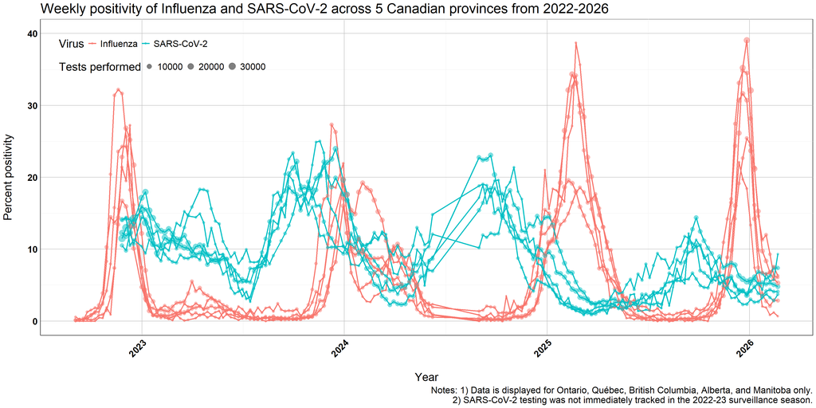

```r
# 2.2.1 Adjust axis tick labels

# Pass along the dataset
respFinalPop.df %>%
  # Filter for 2 viruses and 5 provinces
  filter(
         virus %in% c("Influenza", "SARS-CoV-2"),
         reportingLaboratory %in% top5Provinces
         ) %>%

  ggplot() +
    # 2. Aesthetics
    aes(x = endingDate, y = percentPositive, colour = virus) +

    # Theme elements
    # Start with a base theme
    lec03.theme +

    ### 2.2.1 Adjust the x-axis text
    theme(axis.text.x = element_text(angle = 45,  # Rotate 90
                                     hjust = 1,   # Right-justify
                                     vjust = 1)   # Place text at the top, "vertically" on axis tick

    ) +

    # Add labels to our plot
    labs(title = "Weekly positivity of Influenza and SARS-CoV-2 across 5 Canadian provinces from 2022-2026",
         x = "\nYear",
         y = "Percent positivity\n",
         colour = "Virus",
         size = "Tests performed",
         caption = "Notes: 1) Data is displayed for Ontario, Québec, British Columbia, Alberta, and Manitoba only.\n 2) SARS-CoV-2 testing was not immediately tracked in the 2022-23 surveillance season.") +


    # 3. Scaling
    # Set the y-axis upper limit to 40
    ylim(NA, 40) +

    # 4. Geoms
    # Add a line and group based on lab+virus
    geom_line(aes(group = interaction(reportingLaboratory, virus)), linewidth = 1) +

    # Add a point for each data but make it's size based on the number of tests
    geom_point(aes(size = tests), alpha = 0.5)
```

### 2.2.2 Relabel continuous axis ticks by altering `limits` and `breaks`

Much of your quantitative data will usually come as a continuous series of values. We’ve played around with these scales before using `scale_*_log10` in lecture. Similarly, we can alter continuous axes without necessarily transforming them. This is accomplished via the `scale_*_continuous()` layer. With these types of layers, we have access to parameters like:

- `breaks`, `minor_breaks`: a numeric vector of positions OR a function that takes the limits as input and returns breaks as output for the parameter specified.
- `n.breaks`: an integer to suggest the number of major breaks. The plotting algorithm may alter this value to ensure nice break labels. This will only work if `breaks = waiver()` (the default for `breaks`).
- `labels`: a character vector matching labels to the major breaks.
- `limits`: a numeric vector `c(lower, upper)`

Let’s break our y-axis into major tick-marks at every %5 by altering `scale_y_continuous()` with the `seq()` function. We will leave the previous `ylim()` layer within the code and see how that is affected, even after we set it to a very high value!

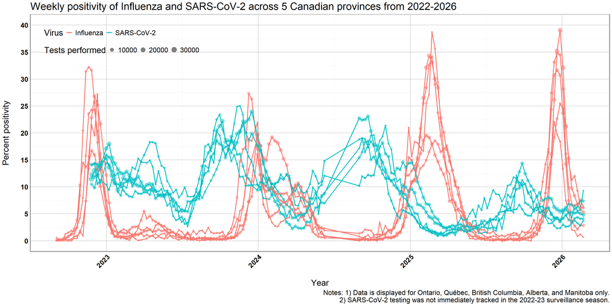

```r
# 2.2.2 Change up our y-axis by adding extra tick marks

# Save the plot to a ggplot object
respLine.plot <-

  # Pass along the dataset
  respFinalPop.df %>%
  # Filter for 2 viruses and 5 provinces
  filter(
         virus %in% c("Influenza", "SARS-CoV-2"),
         reportingLaboratory %in% top5Provinces
         ) %>%

  ggplot() +
    # 2. Aesthetics
    aes(x = endingDate, y = percentPositive, colour = virus) +

    # Theme elements
    # Start with a base theme
    lec03.theme +

    # Adjust the x-axis text
    theme(axis.text.x = element_text(angle = 45,  # Rotate 90
                                     hjust = 1,   # Right-justify
                                     vjust = 1)   # Place text at the top, "vertically" on axis tick

    ) +

    # Add labels to our plot
    labs(title = "Weekly positivity of Influenza and SARS-CoV-2 across 5 Canadian provinces from 2022-2026",
         x = "\nYear",
         y = "Percent positivity\n",
         colour = "Virus",
         size = "Tests performed",
         caption = "Notes: 1) Data is displayed for Ontario, Québec, British Columbia, Alberta, and Manitoba only.\n 2) SARS-CoV-2 testing was not immediately tracked in the 2022-23 surveillance season.") +

    # 3. Scaling
    # This line will be overridden by the following layer! So it really has no place anymore
    # To prove it, we'll set the upper limit to "OVER 9000!"
    ylim(NA, 9001) +

    ### 2.2.2 Change our y-axis breaks
    scale_y_continuous(limits = c(0, 40), breaks = seq(0, 40, 5)) +

    # 4. Geoms
    # Add a line and group based on lab+virus
    geom_line(aes(group = interaction(reportingLaboratory, virus)), linewidth = 1) +

    # Add a point for each data but make it's size based on the number of tests
    geom_point(aes(size = tests), alpha = 0.5)
# Display the plot
respLine.plot
```

### 2.2.3 Relabel discrete axes and legend labels in `scale_*_discrete()`

For various reasons, you may have categorical or grouped data with unusual names. It may be convenient to code your data this way but letting `ggplot2` assign these to your axes or labels may not be suitable. Instead, you can manually rename them using the `labels` parameter with your various `scale_*_discrete()` layers.

When manually labeling your categories be sure to supply a vector with the correct number of arguments to match the number of levels in your categories or groups.

Let’s revisit something similar to our *grouped violin plot with inset boxplots* from last week.

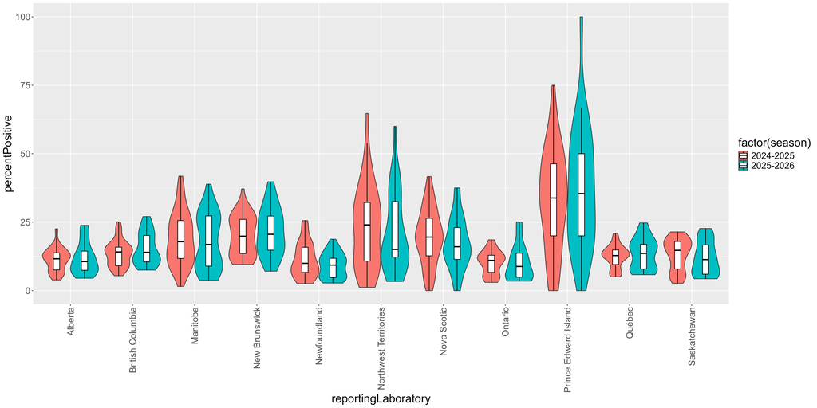

In the above figure, our x-axis is a series of provinces. We’ll modify those in the plot (rather than the data frame) to a format that that uses the initials of our provinces instead.

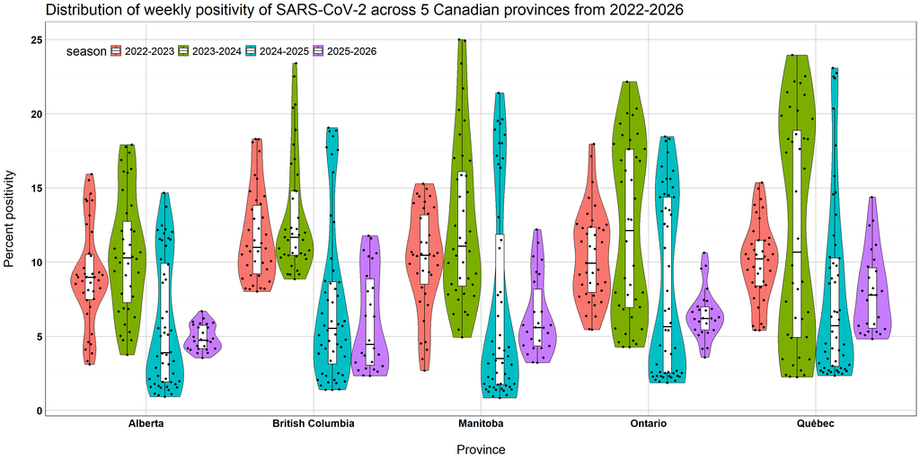

```r
# 2.2.3 Make a violin/boxplot combo

respFinalPop.df %>%
  filter(reportingLaboratory %in% top5Provinces,
         virus == "SARS-CoV-2",
         ) %>%
  ggplot() +
    # 2. Aesthetics
    aes(x = reportingLaboratory, y = percentPositive) +

    # Start with a base theme
    lec03.theme +

    # Add labels to our plot
    labs(title = "Distribution of weekly positivity of SARS-CoV-2 across 5 Canadian provinces from 2022-2026",
         x = "\nProvince",
         y = "Percent positivity\n") +

    # 3. Scaling
    # Reset the boxplot outline colours to black
    scale_colour_manual(values = rep("black", 4)) +

    # 4. Geoms
    # Add a violin plot and fill based on season
    geom_violin(scale = "width", aes(fill = season)) +

    # Add a boxplot and colour based on season
    geom_boxplot(aes(colour = season),
                 position = position_dodge(width=0.9),
                 width = 0.2,
                 outliers = FALSE) +

    # Add the points back in
    geom_quasirandom(aes(group = season), dodge.width = 0.9, width = 0.10)
```

### 2.2.3.1 Simplify your x-axis list

There are a few factors to consider with our province names when replacing them. For categorical values, you must follow the same order as the levels (if a factor) or the logical order of the values (ie alphabetical or ordinal). If you fail to do this properly, you will be labeling your x-axis values incorrectly!

For our province names, we can see that they are listed in alphabetical order. We’ll replace these names with the Canada Post standardized initials and save that version as `top5Provinces_initials`

```r
# Create a new top-5 list of province names in alphabetical order

top5Provinces_initials <- c("AB", "BC", "MB", "ON", "QC")

top5Provinces_initials
```

```
## [1] "AB" "BC" "MB" "ON" "QC"
```

### 2.2.3.2 Use `scale_x_discrete()` to relabel your x-axis values

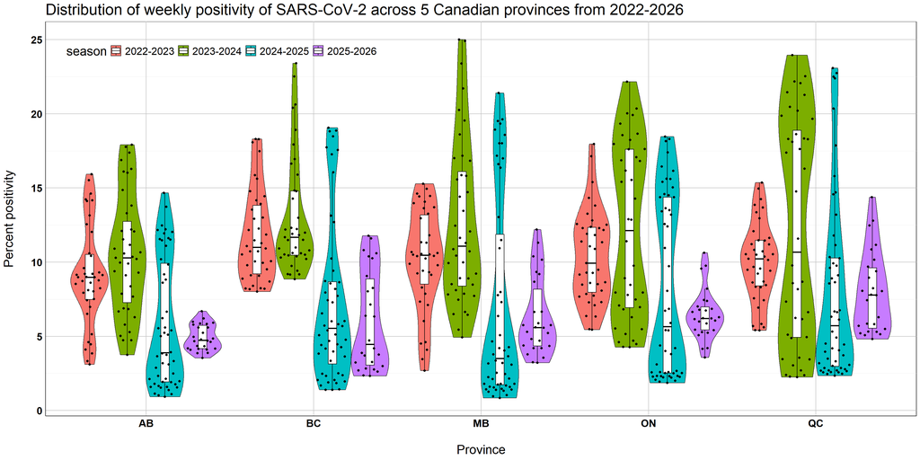

```r
### 2.2.3.2 replacing x-axis labels

respViolin.plot <-

  respFinalPop.df %>%
  filter(reportingLaboratory %in% top5Provinces,
         virus == "SARS-CoV-2",
         ) %>%
  ggplot() +
    # 2. Aesthetics
    aes(x = reportingLaboratory, y = percentPositive) +

    # Start with a base theme
    lec03.theme +

    # Add labels to our plot
    labs(title = "Distribution of weekly positivity of SARS-CoV-2 across 5 Canadian provinces from 2022-2026",
         x = "\nProvince",
         y = "Percent positivity\n") +

    # 3. Scaling
    # Reset the boxplot outline colours to black
    scale_colour_manual(values = rep("black", 4)) +

    ### 2.2.3.2 Set the labels of our x-axis categories
    scale_x_discrete(labels=top5Provinces_initials)+

    # 4. Geoms
    # Add a violin plot and fill based on season
    geom_violin(scale = "width", aes(fill = season)) +

    # Add a boxplot and colour based on season
    geom_boxplot(aes(colour = season),
                 position = position_dodge(width=0.9),
                 width = 0.2,
                 outliers = FALSE) +

    # Add the points back in
    geom_quasirandom(aes(group = season), dodge.width = 0.9, width = 0.10)

# Display the plot
respViolin.plot
```

## 2.3.0 Alter your legends with the `guide` parameter or `guides()` layer

Nearly there with updating this plot! We’ve relabeled the the x-axis categories but we’d like to make some additional changes to our legend. Previously we used the `labs()` layer to handle this aspect but this time around we really want to also alter the *labels* of our data categories to simplify them. For instance, instead of 2022-2023, we could use just ’22 as the surveillance season. Before we get into that, let’s talk a little more about legends.

Normally you can let `ggplot2` take the wheel and automatically generate guides for you. Whenever you set colour/fill/linetype etc in your aesthetics, this will generate a separate legend for each independent variable used to define these characterstics. When the groups are mapped in the same way (i.e. the same variables AND labels!) between different aesthetics, the legends may be combined. We can see this in our current legend where we have our colours AND our boxes in the same legend.

There will be instances, however, when you need to adjust your legend or get rid of it all together. This could range from titles, to combining your guides across different aesthetics commands. You could, for instance, question if we even really need the boxes as part of our legend!

There are a number of ways to achieve the same result when working with guides and we’ll go through a number of examples. First, however, we should discuss the *types* of legends:

| guide | short call | Description |
| --- | --- | --- |
| guide_legend() | legend | The base prototype of the legend which integrates how geoms are mapped into values. |
| guide_bins() | bins | A binned version of legends which places ticks between keys and has its own small axis |
| guide_colourbar() | colourbar | For mapping continous colour/fill scales from using `scale_fill_*()` and `scale_colour_*()`. |
| guide_coloursteps() | coloursteps | A version of guide_colourbar() except for binned colour and fill scales rather than gradients. |
| none | NA | Suppress the legend as specified |

We briefly saw the use of a colourbar in our last lecture when using a continuous variable to set the colour of our barplots. This appeared automatically when we used a continuous variable to colour our barplot (see **Lecture 02, section 3.2.1**). Each type has it’s own use depending on how you want to describe your data. Within each of the guide types, you can update parameters about text within the legend.

| Component | Sub-components |
| --- | --- |
| title | name, position, theme, hjust, vjust |
| label | name, position, theme, hjust, vjust |
| key | width, height |
| order | you can determine the order of the guide amongst others using integers [1:99]. 0 sets order by an algorithm |
| other | direction of guide, number of rows/cols |

So where can you use these methods?

### 2.3.1 Use `scale_*()` to set guide parameters

Within each `scale_*()` you declare you can set the parameter `guide` to one of the above guide types. To exclude a legend for that particular type, set the value to `none`.

Some layer options you may work with here are `scale_fill_discrete()`, `scale_shape_manual()` and `scale_colour_continuous()`

- some of which we’ve seen in previous lectures. Notice that `fill`, `shape` and `colour` are all [aesthetic parameters](https://ggplot2.tidyverse.org/reference/aes_group_order.html) we can [change in our data mapping](https://ggplot2.tidyverse.org/articles/ggplot2-specs.html).

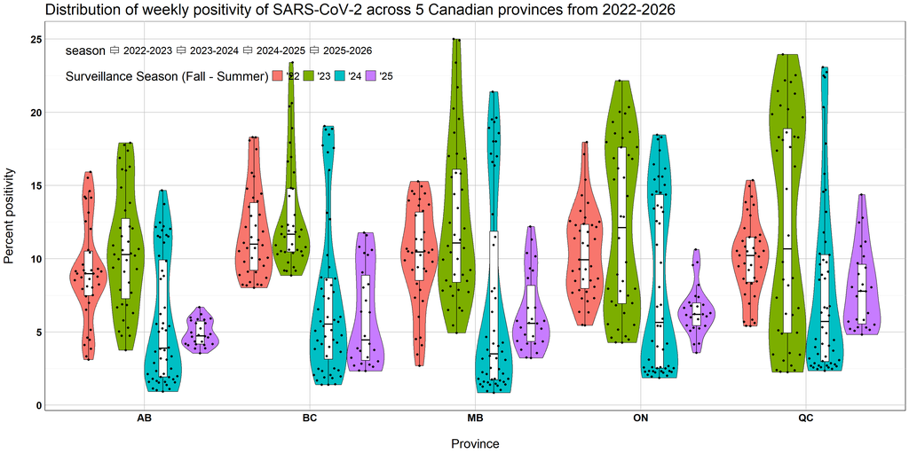

```r
respViolin.plot +
  ### 2.3.1 Change our guide details
  scale_fill_discrete(name = "Surveillance Season (Fall - Summer)",             # Guides name
                      labels = c("'22", "'23", "'24", "'25"))                   # Relabel categories
```

### 2.3.2 Use the `guides()` layer to manipulate multiple guides

Across 2 geoms we’ve generated 2 aesthetic groups: `fill` and `colour`. Remember when we said that `ggplot` would take the wheel and generate legend/guide information automatically? Well this is a case where the two were mapping by the same variable (`season`) so they were combined into a single legend. When we took the time to change the title and labels of the `fill` guide, however, it was broken away from the other `geom_boxplot` guide for `colour`.

In a case like this we use the `guides()` layer to set multiple guides at once using the scale types as parameters ie colour, size, shape. Much like `labs()` it gives us centralized access to guide format and settings, allowing us to quickly rectify our problem. In this case, we really don’t need the `colour` aesthetics, so we’ll simply get rid of them.

Note that we could also use another layer like `scale_colour_discrete()` and set `guide="none"` but sometimes it is nicer to centralize your code a little.

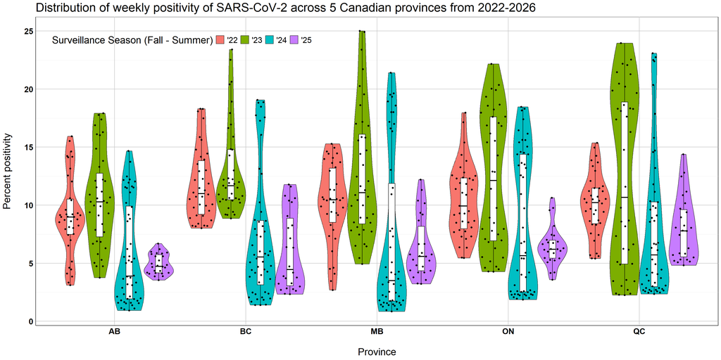

```r
# Adjust the fill scale layer for the demographics plot

respViolin.plot +

  ### 2.3.2 Use the guides() layer and get rid of the colour legend
  guides(fill = guide_legend(title = "Surveillance Season (Fall - Summer)"),
         colour = "none"
         ) +

  # Change our guide details
  scale_fill_discrete(labels = c("'22", "'23", "'24", "'25"))                   # Relabel categories
```

**Try to minimize your layers:** In our above example we had to use **scale_fill_discrete()** and **guides()** because we needed to manipulate multiple guides but only a couple in a very simple way. This format, however, might not always be the best choice. For instance, suppose you wanted to explicitly choose your violin colours? Then a **scale_fill_manual()** layer would be required, at which point you need to decide, will you set your guide format all in this layer or work with a separate **guides()** layer? Depending on the complexity of your guides (as we’ll revisit later) it may be easier to keep them centralized. In other cases, you may want to set them within their own **scale_*()** layers in case you want to make changes to specific layer details more centralized. It’s a balance that will be struck between your specific needs but try to be thoughtful about it to save yourself some pain in editing your code later on.

### 2.4.0 Use `scale_size()` to adjust `geom_point()` sizes

This layer uses many of the same parameters including `name`, `breaks`, `labels` and `range`. In this case, we’ll set the `range` of our size points

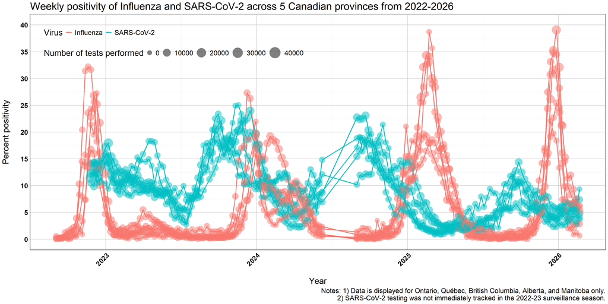

[figure not shown]

```r
# 2.4.0 update the size range of our point

respLine.plot +

  ### 2.4.0 Update the range for your size points
  scale_size(name = "Number of tests performed",
             range = c(5, 12),
             limits = c(0, 40000))
```

You could rely on the basic colour palette but you’re better off picking your own colours!